MORE ON FUNCTIONS: ARGUMENTS, CREATING, PRINTING, SAVING RESULTS, RETURNING RESULTS

# Introduction—-

# Whether your dealing with data types, reading in data, or other analytic tasks

# a fundamental principle of data analytic languages, and programming in

# general, is to avoid repeating code. This concept is often abbreviated as DRY:

# Don’t repeat yourself. One reason why you should not repeat code is because

# it’s a waste of time. Repeating code also leads to more lines of code to

# maintain.

# The opposite of DRY code is WET code in which you write out the process every

# time.

# One way to avoid using WET code is to package a process or routine into a

# function. In this lesson I assume that you’ve already had some experience using

# functions in R. So, I want to dive deeper into functions so that you can use

# them more effectively. I think a great way to learn about functions is to

# create some yourself.

# You may have already used some functions, but I want to share more details

# about how to use and create them.

# Arguments to functions—-

# Also known as parameters. With respect to a function, they are the variables.

# The process performed by the function will not change, but the output will

# change based on the arguments.

```r
?log # In the help, there are two arguments: x, and base. The = exp(1) after the base means that there's a default value that will be used if you don't assign it a value.
```

```
## starting httpd help server ... done
```

```r
log(x = 100, base = 10) # You can explicitly identify the values for each argument
```

```
## [1] 2
```

```r
log(100, 10) # But you don't have to if they come in the order that the arguments are taken
```

```
## [1] 2
```

```r
log(base = 10, x = 100) # You can put them out of order if you explictly identify them
```

```
## [1] 2
```

```r
?sum # In the help, there are two arguments: ..., and na.rm. The ellipsis ... means that the number of arguments can vary
sum(1,3,5)
```

```
## [1] 9
```

# Creating functions—-

# Let’s create a function that uses the built-in cars dataset

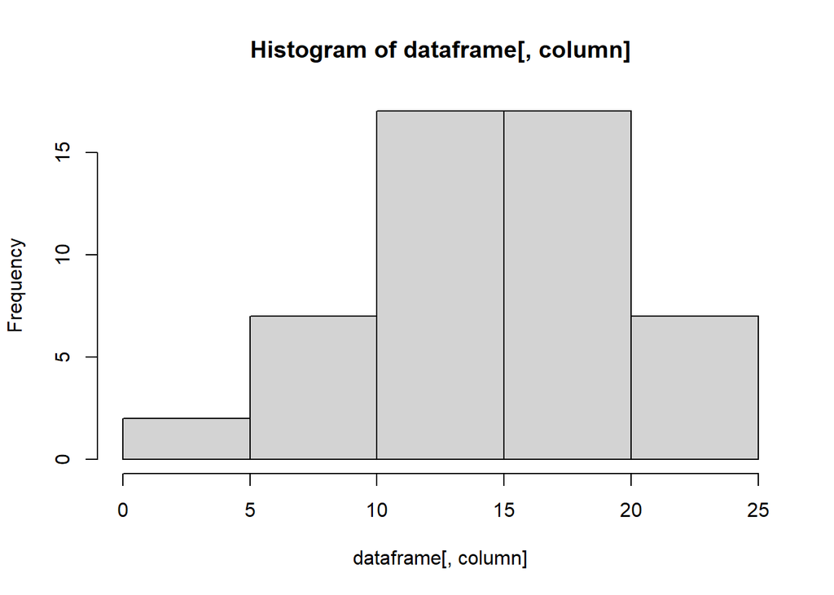

```r
?cars
summarizeAndPlot <- function(dataframe = cars, column = 'speed'){
  summary(dataframe)
  paste0('The value in row 1, column 1 is: ', dataframe[1,1])
  paste0('The value in row 2, column 2 is: ', dataframe[2,2])
  hist(dataframe[,column])
}

summarizeAndPlot() # Notice that it prints the histogram, but not the summary stats or other lines of text. It will only print text if it comes last.
```

# Printing—- # Give instructions to print the summary statistics

```
##      speed           dist
##  Min.   : 4.0   Min.   :  2.00
##  1st Qu.:12.0   1st Qu.: 26.00
##  Median :15.0   Median : 36.00
##  Mean   :15.4   Mean   : 42.98
##  3rd Qu.:19.0   3rd Qu.: 56.00
##  Max.   :25.0   Max.   :120.00
## [1] "The value in row 1, column 1 is: 4"
## [1] "The value in row 2, column 2 is: 10"
```

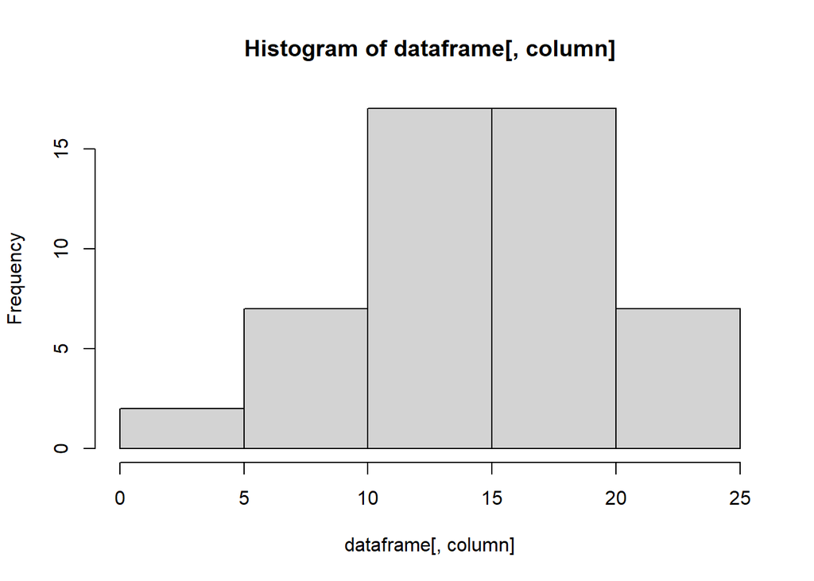

```r
summarizeAndPlot <- function(dataframe = cars, column = 'speed'){
  print(summary(dataframe))
  print(paste0('The value in row 1, column 1 is: ', dataframe[1,1]))
  print(paste0('The value in row 2, column 2 is: ', dataframe[2,2]))
  hist(dataframe[,column])
}
summarizeAndPlot() # This now prints the summary statistics and the other two lines of text.
```

# Let’s test it out on another dataset

```
##      Time           OperationType        BarCode          CashierName
##  Length:8899        Length:8899        Length:8899        Length:8899
##  Class :character   Class :character   Class :character   Class :character
##  Mode  :character   Mode  :character   Mode  :character   Mode  :character
##
##
##
##
##    LineItem          Department          Category         CardholderName
##  Length:8899        Length:8899        Length:8899        Length:8899
##  Class :character   Class :character   Class :character   Class :character
##  Mode  :character   Mode  :character   Mode  :character   Mode  :character
##
##
##
##
##  RegisterName       StoreNumber        TransactionNumber  CustomerCode
##  Length:8899        Length:8899        Length:8899        Length:8899
##  Class :character   Class :character   Class :character   Class :character
##  Mode  :character   Mode  :character   Mode  :character   Mode  :character
##
##
##
##
##       Cost               Price             Quantity        Modifiers
##  Min.   :-189.0400   Min.   :-322.810   Min.   : 1.000   Min.   :-2.5200
##  1st Qu.:   0.1100   1st Qu.:   4.500   1st Qu.: 1.000   1st Qu.: 0.0100
##  Median :   0.1100   Median :  12.020   Median : 1.000   Median : 0.0100
##  Mean   :   0.2108   Mean   :   9.612   Mean   : 1.177   Mean   : 0.6548
##  3rd Qu.:   0.1100   3rd Qu.:  14.680   3rd Qu.: 1.000   3rd Qu.: 1.0800
##  Max.   : 189.0300   Max.   :  24.630   Max.   :36.000   Max.   :57.5500
##                      NA's   :562
##     Subtotal         Discounts           NetTotal            Tax
##  Min.   :-322.80   Min.   : -0.0300   Min.   :-322.77   Min.   :-25.340
##  1st Qu.:   5.24   1st Qu.: -0.0300   1st Qu.:   4.87   1st Qu.:  0.410
##  Median :  13.10   Median : -0.0300   Median :  13.13   Median :  1.040
##  Mean   :  15.10   Mean   :  0.7626   Mean   :  14.34   Mean   :  1.131
##  3rd Qu.:  15.76   3rd Qu.: -0.0300   3rd Qu.:  15.79   3rd Qu.:  1.230
##  Max.   :3328.12   Max.   :951.8300   Max.   :3328.15   Max.   :261.260
##                                                         NA's   :341
##     TotalDue
##  Min.   :-348.11
##  1st Qu.:   5.68
##  Median :  14.17
##  Mean   :  15.88
##  3rd Qu.:  17.02
##  Max.   :3589.41
##  NA's   :341
## [1] "The value in row 1, column 1 is: 2017-01-26T21:18:00Z"
## [1] "The value in row 2, column 2 is: SALE"
```

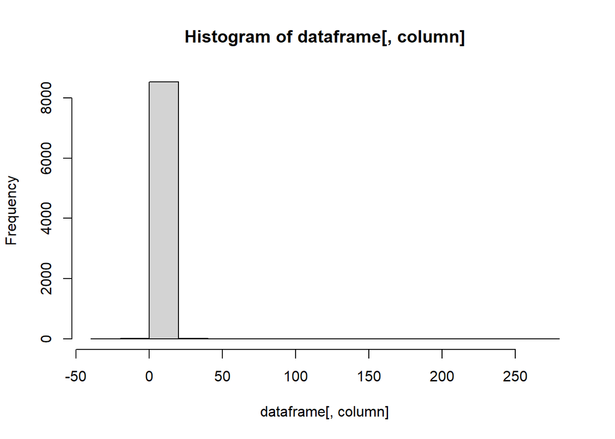

```r
j17i <- read.csv('jan17Items.csv', sep = ',') # Read in the jan17Items.csv dataset
summarizeAndPlot(j17i, 'Tax') # It works well!
```

# Saving results—- # Modify the function to return the summary statistics. # You can save whatever is returned from a function into an object